# hw3_611

Shilin Yu

2024-09-18

Requirement: 1. Submit this homework as an RMarkdown file and the additional files requested in part 7 2.We will assume that the data set is located in the same directory as the Rmd file AND that it is the working directory.

1. Load the data into a tibble data frame and do the following things • print the “problems” data frame. • rename the columns so they are less redundant - we’re only working with dogs here so we can use the column names: name, gender, birth_year, breed, zipcode, issue_date, expiration_date and extract_year. You can rename columns in a lot of ways but I recommend using the function `rename` or the function `transmute` in this case. Look up the documentation to see how they work. Make sure you are looking at the documentation for the dplyr functions • reduce the data down to the complete cases without getting fancy about it. Make sure print out the row count before and after. You’ll want to use the functions sprintf and cat. Both functions documentation will tell you how to use them.

```
## # A tibble: 30 × 8
##    AnimalName AnimalGender AnimalBirthYear BreedName   ZipCode LicenseIssuedDate
##    <chr>      <chr>                  <dbl> <chr>         <dbl> <chr>
##  1 LOLA       F                       2017 Terrier mix   11372 04/11/2018
##  2 MAXX       M                       2017 Papillon      10013 09/20/2018
##  3 RIN        M                       2017 Terrier mix   10075 10/05/2018
##  4 KUMA       F                       2012 Pomeranian    11238 11/12/2019
##  5 CASEY      M                       2014 Labrador R…   10019 01/09/2021
##  6 BAWOO      M                       2017 Jindo Dog,…   10019 02/19/2021
##  7 KOBE       M                       2019 Shih Tzu      11427 04/13/2021
##  8 UNKNOWN    F                       2021 Brussels G…   10036 02/10/2022
##  9 LEO        M                       2012 Labrador R…   10307 02/18/2022
## 10 DOGMAN     M                       2020 Poodle, Mi…   10314 02/21/2022
## # ℹ 20 more rows
## # ℹ 2 more variables: LicenseExpiredDate <chr>, `Extract Year` <dbl>
```

```
## Before removing incomplete cases there were 616890 rows and now there are 615549 rows.
##  (1341 removed)
```

2. Compare the number of distinct rows to the number of total rows. Print this out. Find the non-distinct rows and display them. In your RMarkdown file make some notes about the duplicate lines.

```
## Before removing non-distinct rows there were 615549 rows and now there are 575944  distinct rows.
##  (39605 removed)
```

```
## # A tibble: 39,549 × 8
## # Groups:   name, gender, birth_year, breed, zipcode, issue_date,
## #   expiration_date, extract_year [39,549]
##    name  gender birth_year breed zipcode issue_date expiration_date extract_year
##    <chr> <chr>       <dbl> <chr>   <dbl> <chr>      <chr>                  <dbl>
##  1 MOZZ… F            1991 Germ…   10021 09/15/2020 09/15/2021              2022
##  2 DIEG… M            1992 Germ…   10014 02/05/2021 01/30/2022              2022
##  3 TOCC… F            1993 Schn…   11231 02/04/2021 03/29/2022              2022
##  4 COCOA F            1996 Labr…   11375 08/24/2020 08/24/2021              2022
##  5 ZIGGY F            1997 Hava…   10025 09/30/2020 05/16/2021              2022
##  6 PEAN… F            1997 Jack…   10023 01/13/2021 02/24/2022              2022
##  7 CAPO… M            1998 Mini…   10038 02/13/2020 03/02/2021              2022
##  8 BROW… M            1998 Cock…   11378 01/20/2020 01/20/2023              2022
##  9 RUSTY M            2016 Bull…   10025 05/15/2018 05/11/2023              2023
## 10 TRIX… F            2005 Pugg…   10301 10/05/2020 11/29/2023              2022
```

[output cut: 41 more lines]

3. Use ggplot to graph the number of dogs born on a given year from the start of the data set. Then make a second plot restricted to years with a non-trivial number of dogs.

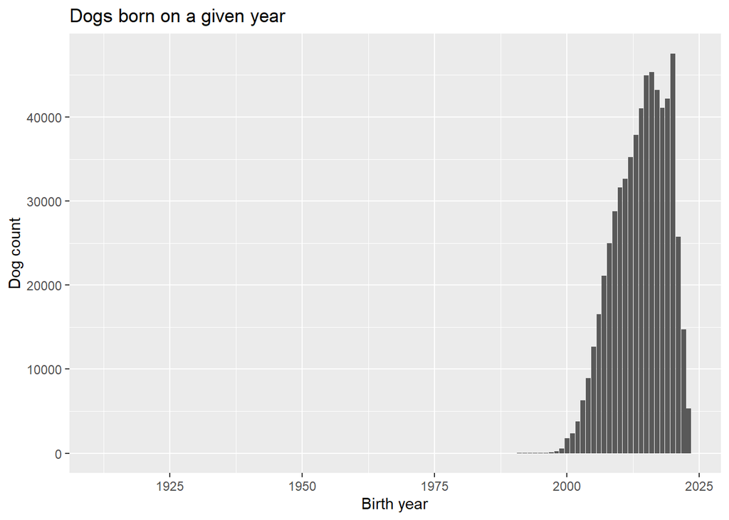

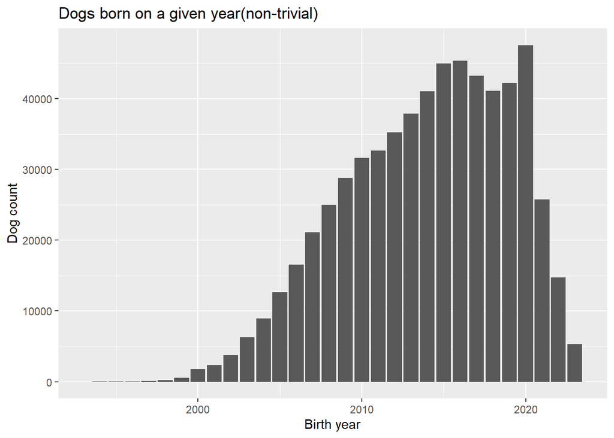

4. In lab we became aware of the fact that that we can’t really identify unique dogs in this data set. The chance of two lines representing the same dog increases, however, if their name, gender, birth year, breed, and zip code are all the same. If we make this assumption, how many unique dogs are in the data set? Produce a filtered data set with unique dogs under the assumption. Print the row count before and after this assumption is enforced.

```
## Under the new assumption for the complete dataset, Before removing non-distinct rows there were 615549 rows and now there are 312780  distinct rows.
##  (302769 removed)
```

5. Create a new data frame which calculates the total number of dogs born on a give year and put it aside. Then calculate the total number of dogs with a given name on a given year in a second data frame. Do a join between the two and then calculate the rate of each dog name as a function of year. What is the most popular dog name in 1999? In 2024?

A: In my data set not dog birth in 2024 I choose to show dog name in 2023

```
## The most popular dog name in 1999 is: BUDDY , and the most popular dog name in 2023 is: LUNA
```

Create a plot showing the rate of the most popular dog name in 1999 over time. Create a second plot showing the popularity of the most popular dog name in 2023. Put both plots on the same figure.

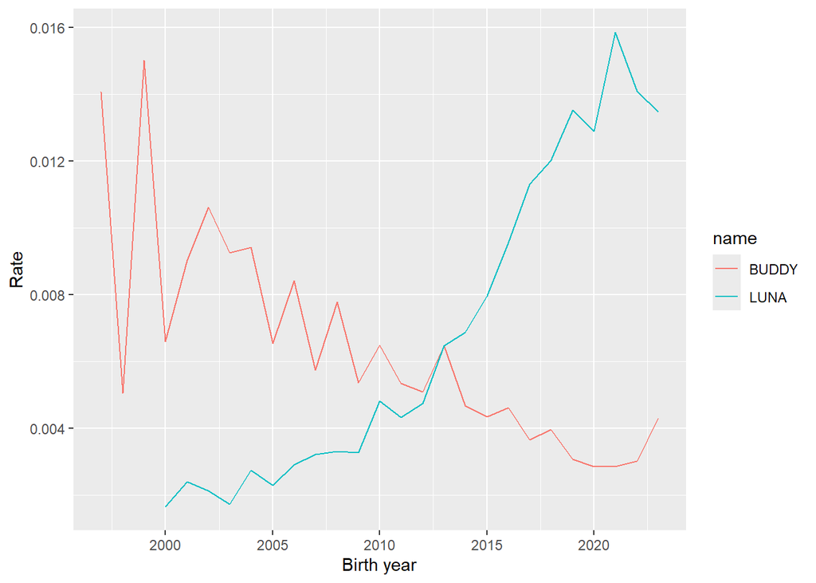

7. When we do reproducible data scence we separate each step of our analysis into a separate script file which loads what it needs when it starts and saves its results on exit. Split this homework into as many scripts as you feel are appropriate and submit them along with this homework.

readr::write_csv(data,“processdata.csv”) readr::write_csv(disdata3,“assumpt_dis_data.csv”)

[output not shown]

8. Create a makefile for this set of processing steps.